# Project 3 Technical Report

##### Analysis by Bea

Our monthly productions, costs, and profits have already been calculated in our Data Transformation section. The product line costs per units were calculated in Productline Regression Modeling using R Studios multiple linear regression function. The CPU’s were implemented into our datasets by month and product line, then we combined the sales dataset and production data set in Joining Sales and Monthly Production by Productline. Within this section, we gathered our sales per product line by creating individual columns representing the min, average, and max sales per product. Items were sold at varying prices and we will use these three variables to determine price ranges we should stick with. Within the same section our CPU’s were subtracted by our selling price to determine our profits. The finalized conjoining and calculations of the data reside within the `Final Sales x Production Productline` CSV. This data set will be used to visualize our cost and profit analyses, and the analysis will be conducted by Bea.

|  | Month | PRODUCTLINE | factory_id | TOTAL_UNITS_PRODUCED | REGRESSION_CPU | REG_FACTORY_BASE_COST | REG_PROD_COST_NO_BASE | AVG_PRODUCTION_COST_W_BASE | MIN_PRICE_SOLD | AVG_PRICE_SOLD | MAX_PRICE_SOLD | AVG_SHIPPED_PER_ORDER | TOTAL_SHIPPED | TOTAL_SALES | MIN_PRODUCT_PROFIT | AVG_PRODUCT_PROFIT | MAX_PRODUCT_PROFIT | MIN_TOTAL_REVENUE | AVG_TOTAL_REVENUE | MAX_TOTAL_REVENUE | MIN_TOTAL_PROFIT | AVG_TOTAL_PROFIT | MAX_TOTAL_PROFIT | ACTUAL_TOTAL_PROFIT |
| --- | --- | --- | --- | --- | --- | --- | --- | --- | --- | --- | --- | --- | --- | --- | --- | --- | --- | --- | --- | --- | --- | --- | --- | --- |
| 1 | 2003-01-01 | Classic_Cars | 0 | 11 | 83.72602575163032 | 448.0298500374682 | 920.9862832679335 | 1369.016133305402 | 39.6 | 89.509 | 100 | 33.4 | 334 | 41191.78 | -44.12602575163032 | 5.782974248369683 | 16.27397424836968 | 13226.4 | 29896.006 | 33400 | 11857.3838666946 | 28526.9898666946 | 32030.9838666946 | 39822.7638666946 |
| 2 | 2003-01-01 | Motorcycles | 1 | 57 | 75.09013528539406 | 256.6871241921943 | 4280.137711267461 | 4536.824835459655 |  |  |  |  |  |  |  |  |  |  |  |  |  |  |  |  |
| 3 | 2003-01-01 | Planes | 2 | 25 | 83.10429899486856 | 546.7720032028801 | 2077.607474871714 | 2624.379478074594 |  |  |  |  |  |  |  |  |  |  |  |  |  |  |  |  |
| 4 | 2003-01-01 | Ships | 0 | 123 | 15.90912499274387 | 448.0298500374682 | 1956.822374107496 | 2404.852224144965 |  |  |  |  |  |  |  |  |  |  |  |  |  |  |  |  |
| 5 | 2003-01-01 | Trucks_and_Buses | 1 | 12 | 91.03925839261072 | 256.6871241921943 | 1092.471100711329 | 1349.158224903523 | 47.62 | 88.8490909090909 | 100 | 33.63636363636363 | 370 | 36801.43 | -43.41925839261072 | -2.190167483519815 | 8.96074160738928 | 17619.4 | 32874.16363636364 | 37000 | 16270.24177509647 | 31525.00541146011 | 35650.84177509648 | 35452.27177509648 |
| 6 | 2003-01-01 | Vintage_Cars | 2 | 45 | 66.67280723374103 | 546.7720032028801 | 3000.276325518346 | 3547.048328721226 | 31.2 | 75.73125 | 100 | 35.75 | 572 | 46826.84 | -35.47280723374102 | 9.058442766258977 | 33.32719276625897 | 17846.4 | 43318.275 | 57200 | 14299.35167127877 | 39771.22667127878 | 53652.95167127877 | 43279.79167127877 |
| 7 | 2003-02-01 | Classic_Cars | 0 | 10 | 83.72602575163032 | 448.0298500374682 | 837.2602575163032 | 1285.290107553772 | 100 | 100 | 100 | 40 | 120 | 20464.41 | 16.27397424836968 | 16.27397424836968 | 16.27397424836968 | 12000 | 12000 | 12000 | 10714.70989244623 | 10714.70989244623 | 10714.70989244623 | 19179.11989244623 |
| 8 | 2003-02-01 | Motorcycles | 1 | 15 | 75.09013528539406 | 256.6871241921943 | 1126.352029280911 | 1383.039153473105 | 70.87 | 92.80125 | 100 | 28.625 | 229 | 25783.76 | -4.220135285394051 | 17.71111471460594 | 24.90986471460594 | 16229.23 | 21251.48625 | 22900 | 14846.1908465269 | 19868.44709652689 | 21516.96084652689 | 24400.72084652689 |
| 9 | 2003-02-01 | Planes | 2 | 62 | 83.10429899486856 | 546.7720032028801 | 5152.46653768185 | 5699.23854088473 | 52.64 | 80.8975 | 100 | 38.33333333333334 | 460 | 39205.31 | -30.46429899486856 | -2.206798994868564 | 16.89570100513144 | 24214.4 | 37212.85 | 46000 | 18515.16145911527 | 31513.61145911527 | 40300.76145911527 | 33506.07145911526 |
| 10 | 2003-02-01 | Ships | 0 | 53 | 15.90912499274387 | 448.0298500374682 | 843.1836246154253 | 1291.213474652894 | 56.78 | 80.88333333333334 | 100 | 33.44444444444444 | 301 | 27050.38 | 40.87087500725613 | 64.97420834058947 | 84.09087500725613 | 17090.78 | 24345.88333333334 | 30100 | 15799.56652534711 | 23054.66985868044 | 28808.78652534711 | 25759.16652534711 |

[output cut: 187 more lines]

First is the analysis of our cost per product line…

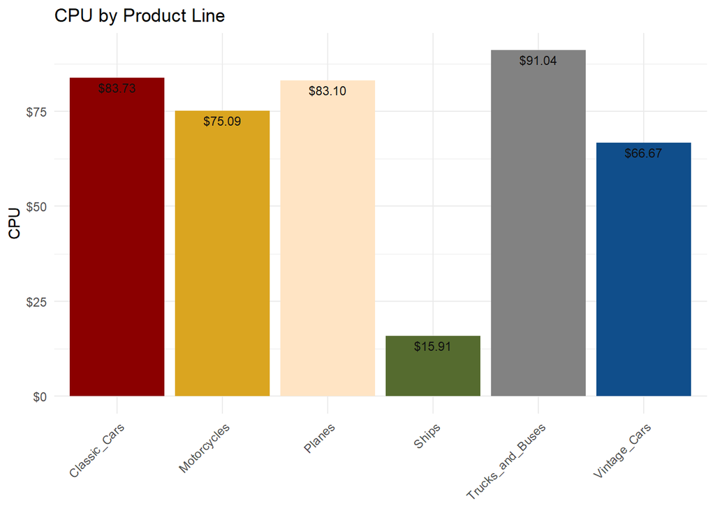

The Bar chart portrays our product line cost per unit. We see that Trucks and Buses are our highest costed items to produce, costing `$91`. Classic cars rise to second at `$83.73` and Planes are our third highest costing at `$83.10`. Noteably, ships are our lowest costing products at `$15.91`. Which is an incredible rate.

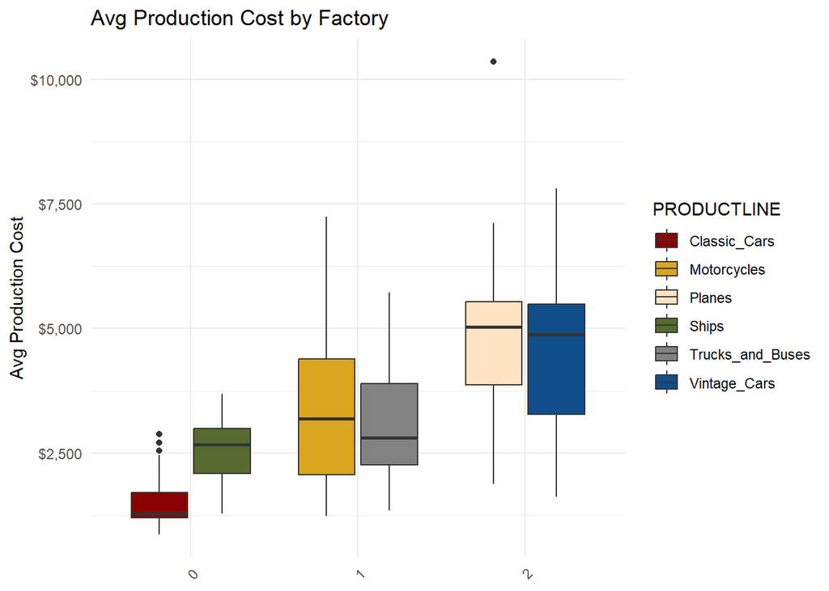

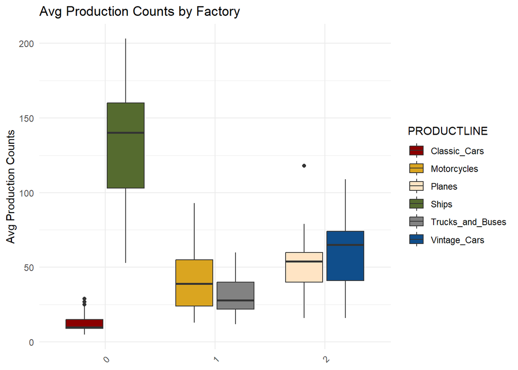

When we observe our production costs by factory and product line, we see that factory 2 has the highest average production costs, maxing over `$7,000` per production type. The average production costs for factory 2 appear appropriate with the two product types, Vintage Cars and Planes, having the second highest production counts coinciding with the higher production costs of planes. Planes have the third highest CPU, but are constructed in the same facility as our second lowest CPU item, Vintage Cars. We may be seeing the heavy production costs of planes influencing Vintage Cars, putting them on similar average production cost levels, regardless of the low CPU Vintage cars have. Despite Classic Cars high production costs, we have very low production counts. We can observe why this case may be because its average production counts lie below 25 units per production. Surprisingly, we have very average production costs for ships even though they have the highest production counts. Our remaining products average in production ranges between 25-75 and their average production costs range between `$2,000 - $6,000`. We have a clear idea of our production costs, now we would like to analyze our revenue and profits…

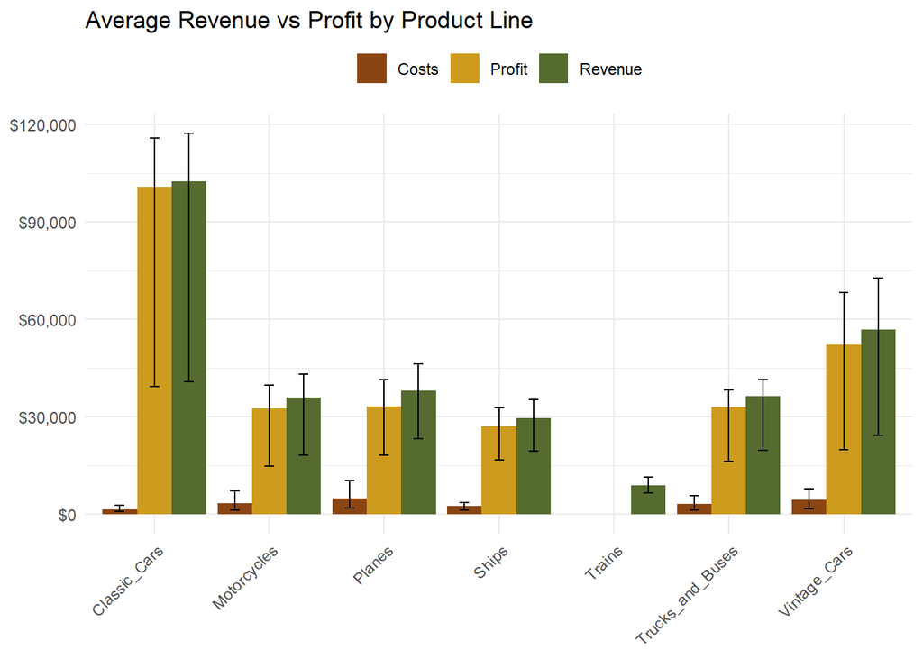

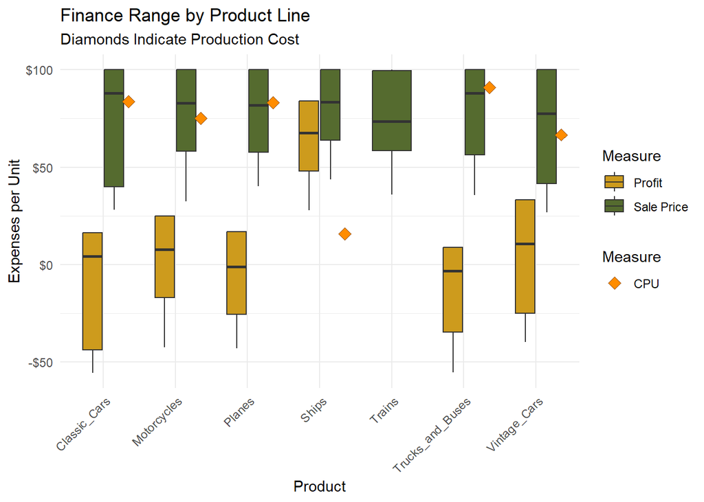

Observing the Bar chart, we see for almost every product line we have revenue and profits exceed an average of `$30,000`. Classic Cars is our highest profiting item, yet we previously observed that it is one of the highest costing items to produce with the lowest amount of production occurring. We also note that Ships are our highest produced item with the lowest cost, and it has one of the lowest average profit and revenue. Our lowest revenue occurs from trains, using the only data we had available. Based on our production costs, production numbers, and average finances, there appears to be a discrepancy between our production and sales data. This may be due to a back stock of items already produced, and we are selling large quantities of back stocked products. We can also note in our finance ranges that our selling points per unit have dropped below our production costs per unit. The Box and Whisker indicates that we have negative profits per unit based on the selling points. Despite the implications that we are loosing money per unit, our sales appear unaffected. Furthering that there is something off with our production data, and it’s correlation could lie within back stocked items.. While our production data appears to have questionable results, we can confirm that we have substantially high profits per product line, but Trains and Ships are our least profitable. We can also conclude that there are instances in which we are selling below our production costs per unit, and should avoid selling below that mark.

## *Forecasting Profits*

**Formula:** > Projected Monthly Profit = Forecasted Units x Average Profit Per Unit

This calculation is applied for each product line across all seven forecast months. The 80% prediction intervals from the STL model are carried through to provide a lower and upper bound on each profit estimate.

#### Step 1: Re-extract STL Forecast Values

```r
fc_store <- list()
pl_forecast <- unique(Final_SalesXProduction_Productline$PRODUCTLINE)
pl_forecast <- pl_forecast[pl_forecast != "Trains"]

for (pl in pl_forecast) {
  submodel <- Final_SalesXProduction_Productline %>%
    filter(PRODUCTLINE == pl) %>%
    arrange(Month) %>%
    tidyr::complete(
      Month = seq.Date(min(Month), max(Month), by = "month"),
      fill = list(TOTAL_UNITS_PRODUCED = 0)
    )

  ts_obj <- ts(submodel$TOTAL_UNITS_PRODUCED,
               start     = c(year(min(submodel$Month)), month(min(submodel$Month))),
               frequency = 12)

  last_date  <- max(submodel$Month)
  target_end <- as.Date("2005-12-31")
  h          <- lubridate::interval(last_date, target_end) %/% months(1)

  stl_model <- stl(ts_obj, s.window = "periodic")
  fc        <- forecast(stl_model, h = h)
  fc$lower[fc$lower < 0] <- 0

  fc_store[[pl]] <- fc
}
```

#### Step 2: Monthly Profit Projection Table

```r
fmt_dollar <- function(x) paste0("$", format(round(x), big.mark = ","))

forecast_months <- seq(as.Date("2005-06-01"), as.Date("2005-12-01"), by = "month")
month_labels    <- format(forecast_months, "%b %Y")

fc_rows <- list()
for (pl in pl_forecast) {
  fc <- fc_store[[pl]]
  fc_rows[[pl]] <- data.frame(
    product_line = pl,
    month_label  = month_labels,
    forecast     = pmax(0, as.numeric(fc$mean)),
    lower80      = pmax(0, as.numeric(fc$lower[, 1])),
    upper80      = pmax(0, as.numeric(fc$upper[, 1]))
  )
}
fc_df <- do.call(rbind, fc_rows)

fc_profit <- merge(fc_df,
                   profit_per_unit[, c("PRODUCTLINE", "avg_profit_per_unit")],
                   by.x = "product_line", by.y = "PRODUCTLINE")

fc_profit$projected_profit <- fc_profit$forecast * fc_profit$avg_profit_per_unit
fc_profit$profit_lo80      <- fc_profit$lower80  * fc_profit$avg_profit_per_unit
fc_profit$profit_hi80      <- fc_profit$upper80  * fc_profit$avg_profit_per_unit
fc_profit$month_label      <- factor(fc_profit$month_label, levels = month_labels)

detail <- fc_profit[order(fc_profit$product_line, fc_profit$month_label),
                    c("product_line", "month_label", "forecast",
                      "avg_profit_per_unit", "projected_profit")]
detail$forecast            <- round(detail$forecast, 1)
detail$avg_profit_per_unit <- fmt_dollar(detail$avg_profit_per_unit)
detail$projected_profit    <- fmt_dollar(detail$projected_profit)
colnames(detail) <- c("Product Line", "Month", "Forecast Units",
                       "Avg Profit/Unit", "Projected Profit")
print(detail, row.names = FALSE)
```

```
##      Product Line    Month Forecast Units Avg Profit/Unit Projected Profit
##      Classic_Cars Jun 2005           18.7         $13,643         $255,488
##      Classic_Cars Jul 2005            7.4         $13,643         $100,810
##      Classic_Cars Aug 2005           15.7         $13,643         $213,712
##      Classic_Cars Sep 2005           11.9         $13,643         $162,903
##      Classic_Cars Oct 2005            8.4         $13,643         $113,972
##      Classic_Cars Nov 2005           10.3         $13,643         $140,076
##      Classic_Cars Dec 2005           16.4         $13,643         $223,337
##       Motorcycles Jun 2005           38.5         $ 1,376         $ 52,969
##       Motorcycles Jul 2005           45.1         $ 1,376         $ 62,054
##       Motorcycles Aug 2005           69.8         $ 1,376         $ 96,039
##       Motorcycles Sep 2005           30.0         $ 1,376         $ 41,266
##       Motorcycles Oct 2005           66.2         $ 1,376         $ 91,079
##       Motorcycles Nov 2005           18.4         $ 1,376         $ 25,300
##       Motorcycles Dec 2005           40.4         $ 1,376         $ 55,636
##            Planes Jun 2005           51.7         $   810         $ 41,864
##            Planes Jul 2005           30.6         $   810         $ 24,736
##            Planes Aug 2005           96.3         $   810         $ 77,988
##            Planes Sep 2005           33.1         $   810         $ 26,810
##            Planes Oct 2005           57.6         $   810         $ 46,632
##            Planes Nov 2005           60.6         $   810         $ 49,048
##            Planes Dec 2005           48.5         $   810         $ 39,232
##             Ships Jun 2005          104.8         $   231         $ 24,229
##             Ships Jul 2005          130.7         $   231         $ 30,222
##             Ships Aug 2005          176.5         $   231         $ 40,825
##             Ships Sep 2005          120.9         $   231         $ 27,954
##             Ships Oct 2005          134.3         $   231         $ 31,065
##             Ships Nov 2005          142.8         $   231         $ 33,019
##             Ships Dec 2005          125.9         $   231         $ 29,130
##  Trucks_and_Buses Jun 2005           38.2         $ 1,350         $ 51,531
##  Trucks_and_Buses Jul 2005           40.3         $ 1,350         $ 54,471
##  Trucks_and_Buses Aug 2005           32.9         $ 1,350         $ 44,405
##  Trucks_and_Buses Sep 2005           31.9         $ 1,350         $ 43,117
##  Trucks_and_Buses Oct 2005           24.6         $ 1,350         $ 33,255
##  Trucks_and_Buses Nov 2005           37.8         $ 1,350         $ 51,078
##  Trucks_and_Buses Dec 2005           34.8         $ 1,350         $ 46,946
##      Vintage_Cars Jun 2005           55.7         $ 1,209         $ 67,395
##      Vintage_Cars Jul 2005           36.7         $ 1,209         $ 44,430
##      Vintage_Cars Aug 2005           53.7         $ 1,209         $ 64,971
##      Vintage_Cars Sep 2005           55.2         $ 1,209         $ 66,769
##      Vintage_Cars Oct 2005           64.6         $ 1,209         $ 78,065
##      Vintage_Cars Nov 2005           88.9         $ 1,209         $107,501
##      Vintage_Cars Dec 2005           38.7         $ 1,209         $ 46,854
```

The table shows forecasted units, average profit per unit, and resulting projected profit for each product line across each month from June to December 2005.

#### Step 3: Total Expected Profit by Product Line (Jun–Dec 2005)

```r
profit_by_pl <- aggregate(
  cbind(total_units  = forecast,
        total_profit = projected_profit,
        lower_80     = profit_lo80,
        upper_80     = profit_hi80) ~ product_line,
  data = fc_profit, FUN = sum
)
profit_by_pl <- profit_by_pl[order(-profit_by_pl$total_profit), ]

pl_out <- profit_by_pl
pl_out$total_units  <- round(pl_out$total_units)
pl_out$total_profit <- scales::dollar(round(pl_out$total_profit))
pl_out$lower_80     <- scales::dollar(round(pl_out$lower_80))
pl_out$upper_80     <- scales::dollar(round(pl_out$upper_80))
colnames(pl_out) <- c("Product Line", "Total Forecast Units",
                       "Projected Profit", "80% CI Lower", "80% CI Upper")
print(pl_out, row.names = FALSE)
```

```
##      Product Line Total Forecast Units Projected Profit 80% CI Lower
##      Classic_Cars                   89       $1,210,299     $507,623
##      Vintage_Cars                  394         $475,986     $267,135
##       Motorcycles                  308         $424,344     $250,892
##  Trucks_and_Buses                  241         $324,803     $175,199
##            Planes                  378         $306,309     $203,585
##             Ships                  936         $216,444     $142,510
##  80% CI Upper
##    $1,912,974
##      $684,836
##      $597,796
##      $474,408
##      $409,034
##      $290,377
```

#### Step 4: Total Expected Profit by Factory (Jun–Dec 2005)

```r
factory_map <- unique(Final_SalesXProduction_Productline[
  !is.na(Final_SalesXProduction_Productline$factory_id),
  c("PRODUCTLINE", "factory_id")
])
names(factory_map)[1] <- "product_line"
factory_map <- factory_map[!duplicated(factory_map$product_line), ]

fc_profit_factory <- merge(fc_profit, factory_map, by = "product_line", all.x = TRUE)
fc_profit_factory$factory_label <- paste0("Factory ", fc_profit_factory$factory_id)

profit_by_factory <- aggregate(
  cbind(total_profit = projected_profit,
        lower_80     = profit_lo80,
        upper_80     = profit_hi80) ~ factory_id,
  data = fc_profit_factory[!is.na(fc_profit_factory$factory_id), ],
  FUN = sum
)
factory_lines <- aggregate(product_line ~ factory_id, data = factory_map,
                            FUN = paste, collapse = ", ")
profit_by_factory <- merge(profit_by_factory, factory_lines, by = "factory_id")
profit_by_factory <- profit_by_factory[order(profit_by_factory$factory_id), ]

fac_out <- profit_by_factory
fac_out$total_profit <- scales::dollar(round(fac_out$total_profit))
fac_out$lower_80     <- scales::dollar(round(fac_out$lower_80))
fac_out$upper_80     <- scales::dollar(round(fac_out$upper_80))
colnames(fac_out) <- c("Factory", "Projected Profit",
                        "80% CI Lower", "80% CI Upper", "Product Lines")
print(fac_out[, c("Factory", "Product Lines",
                   "Projected Profit", "80% CI Lower", "80% CI Upper")],
      row.names = FALSE)
```

```
##  Factory                 Product Lines Projected Profit 80% CI Lower
##        0           Classic_Cars, Ships       $1,426,742     $650,133
##        1 Motorcycles, Trucks_and_Buses         $749,147     $426,091
##        2          Planes, Vintage_Cars         $782,295     $470,720
##  80% CI Upper
##    $2,203,352
##    $1,072,204
##    $1,093,870
```

Product lines are grouped by the factory that produces them to show which facility is expected to contribute most to company performance in the second half of 2005.

#### Step 5: Overall Company Total

```r
overall_profit <- sum(fc_profit$projected_profit, na.rm = TRUE)
overall_lo80   <- sum(fc_profit$profit_lo80,      na.rm = TRUE)
overall_hi80   <- sum(fc_profit$profit_hi80,      na.rm = TRUE)

fmt_dollar <- function(x) paste0("$", format(round(x), big.mark = ","))

cat("=== Company Total Projected Profit: Jun-Dec 2005 ===\n")
```

```
## === Company Total Projected Profit: Jun-Dec 2005 ===
```

```r
cat(sprintf("  Point Estimate : %s\n", fmt_dollar(overall_profit)))
```

```
##   Point Estimate : $2,958,185
```

```r
cat(sprintf("  80%% CI Lower   : %s\n", fmt_dollar(overall_lo80)))
```

```
##   80% CI Lower   : $1,546,944
```

```r
cat(sprintf("  80%% CI Upper   : %s\n", fmt_dollar(overall_hi80)))
```

```
##   80% CI Upper   : $4,369,426
```

The overall company total reflects the cumulative uncertainty across all six product lines. The gap between the lower and upper bounds is wide, consistent with the noisy production history observed in the STL decompositions. These figures should be treated as a directional range rather than precise targets.

#### Profit Projection Visualizations

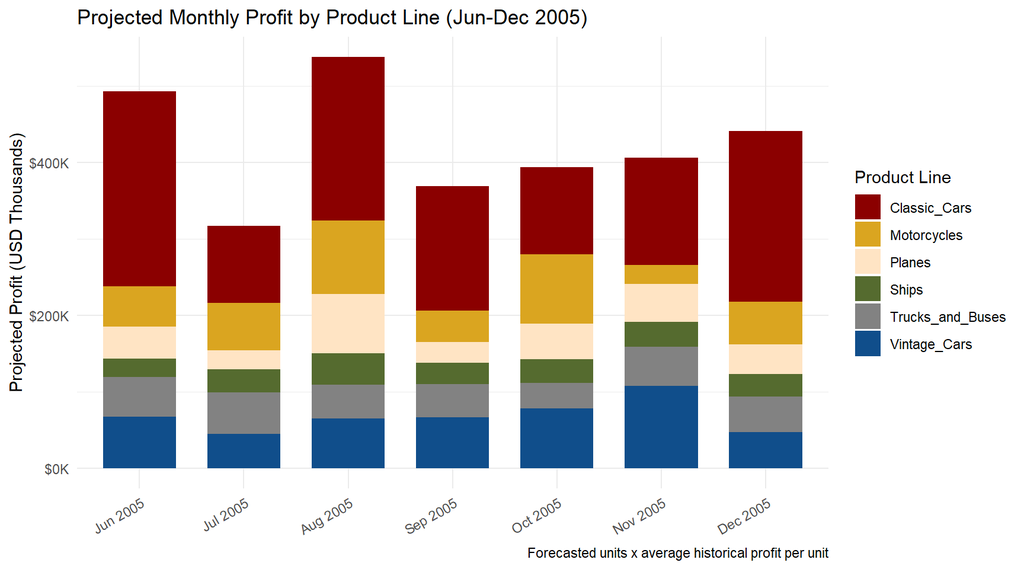

```r
ggplot(fc_profit, aes(x = month_label, y = projected_profit / 1e3,
                       fill = product_line)) +
  geom_col(width = 0.7) +
  scale_fill_manual(values = palette) +
  scale_y_continuous(labels = scales::label_dollar(suffix = "K")) +
  labs(title   = "Projected Monthly Profit by Product Line (Jun-Dec 2005)",
       x       = NULL,
       y       = "Projected Profit (USD Thousands)",
       fill    = "Product Line",
       caption = "Forecasted units x average historical profit per unit") +
  theme_minimal() +
  theme(axis.text.x = element_text(angle = 30, hjust = 1))
```

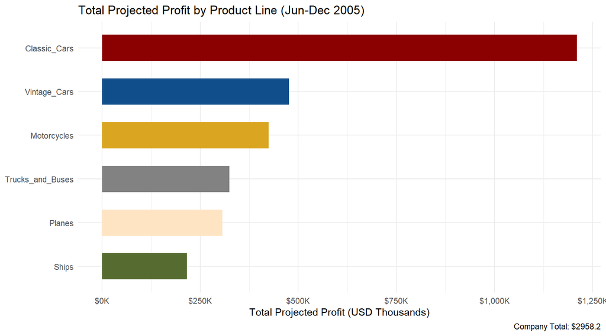

```r
profit_by_pl$product_line <- reorder(profit_by_pl$product_line,
                                      profit_by_pl$total_profit)

ggplot(profit_by_pl, aes(x = total_profit / 1e3, y = product_line,
                          fill = as.character(product_line))) +
  geom_col(width = 0.6, show.legend = FALSE) +
  scale_fill_manual(values = palette) +
  scale_x_continuous(labels = scales::label_dollar(suffix = "K")) +
  labs(title   = "Total Projected Profit by Product Line (Jun-Dec 2005)",
       x       = "Total Projected Profit (USD Thousands)",
       y       = NULL,
       caption = paste0("Company Total: $", round(overall_profit / 1e3, 1))) +
  theme_minimal()
```

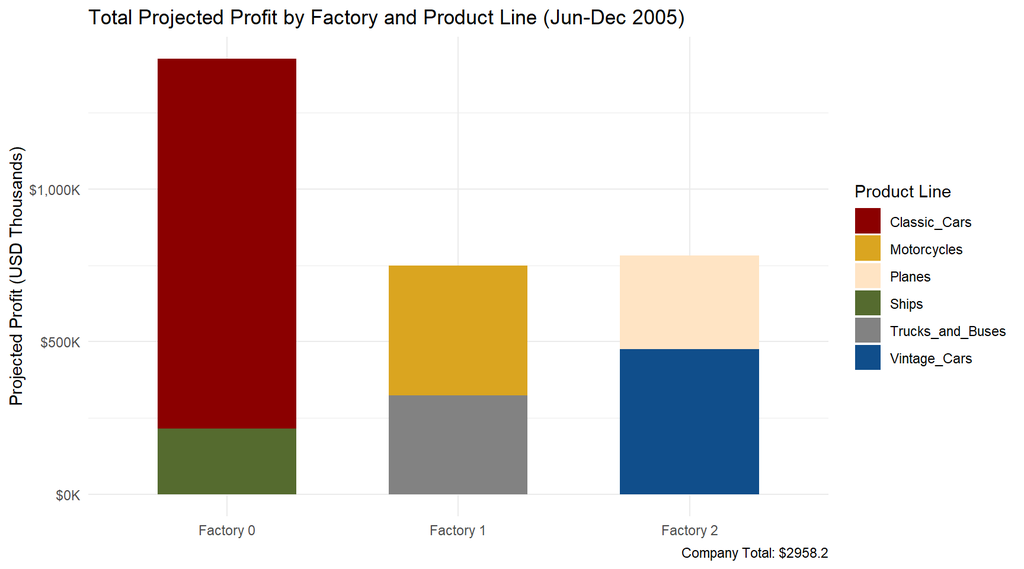

```r
profit_factory_pl <- aggregate(projected_profit ~ factory_label + product_line,
                                data = fc_profit_factory[!is.na(fc_profit_factory$factory_id), ],
                                FUN = sum)

ggplot(profit_factory_pl, aes(x = factory_label, y = projected_profit / 1e3,
                               fill = product_line)) +
  geom_col(width = 0.6) +
  scale_fill_manual(values = palette) +
  scale_y_continuous(labels = scales::label_dollar(suffix = "K")) +
  labs(title   = "Total Projected Profit by Factory and Product Line (Jun-Dec 2005)",
       x       = NULL,
       y       = "Projected Profit (USD Thousands)",
       fill    = "Product Line",
       caption = paste0("Company Total: $", round(overall_profit / 1e3, 1))) +
  theme_minimal()
```

## *Limitations and Assumptions*

While analysis provides strategically grounded projections, several limitations and assumptions should be acknowledged.

### Assumptions

- Historical Patterns: Forecasting models assume past production trends and seasonality will persist through December 2005
- Stable Cost Structure: Average cost per unit is assumed to remain consistent throughout the forecast period
- External Market Influence: The model does not account for micro economic shifts, supply chain disruptions, or fluctuations in demand.
- Accurate Data: All analyses assume historical data is accurate after cleaning and aggregation.

### Limitations

- Model simplicity: Time series models do not account for external drivers such as economic fluctuations or competitor activity.
- No Constraints Modeled: Forecasts assume factories can meet projected production levels without constraints.  
  These limitations suggest that ongoing monitoring of actual production is recommended. Forecasts should also be treated as directional guidance rather than guaranteed outcomes.